# Visualization

**1. Lập bảng cho thấy tần số (frequency), tần suất (relative frequency), mật độ (density), tần số tích lũy (cumulative frequency), tần suất tích lũy (cumulative relative frequency).**

```python
# Các khoảng
intervals = np.array([0, 8, 12, 16, 24, 28, 34, 50])

# Số các khoảng
num_of_intervals = len(intervals)-1

# Độ lớn của các khoảng
intervals_width = np.diff(intervals)

# Tần số của các khoảng
frequency = np.array([4, 6, 12, 28, 8, 6, 4])

# Tần suất của các khoảng
probability = np.round(frequency/np.sum(frequency), 3)

# Mật độ
density = np.round(np.array(probability/intervals_width), 3)

# Tần số tích lũy
cumsum = np.cumsum(frequency)

# Tần suất tích lũy
cumsum_prob = np.round(np.cumsum(probability), 3)


pd.DataFrame({
    "Interval":["{} - {}" .format(intervals[i], intervals[i+1]) for i in range(num_of_intervals)],
    "Frequency" : frequency,
    "Density" : density,
    "Relative Frequency": probability,
    "Cumulative Frequency": cumsum,
    "Cumulative relative frequency": cumsum_prob
})
```

|  | Interval | Frequency | Density | Relative Frequency | Cumulative Frequency | Cumulative relative frequency |
| --- | --- | --- | --- | --- | --- | --- |
| 0 | 0 - 8 | 4 | 0.007 | 0.059 | 4 | 0.059 |
| 1 | 8 - 12 | 6 | 0.022 | 0.088 | 10 | 0.147 |
| 2 | 12 - 16 | 12 | 0.044 | 0.176 | 22 | 0.323 |
| 3 | 16 - 24 | 28 | 0.052 | 0.412 | 50 | 0.735 |
| 4 | 24 - 28 | 8 | 0.030 | 0.118 | 58 | 0.853 |
| 5 | 28 - 34 | 6 | 0.015 | 0.088 | 64 | 0.941 |
| 6 | 34 - 50 | 4 | 0.004 | 0.059 | 68 | 1.000 |

**2. Vẽ biểu đồ histogram.**

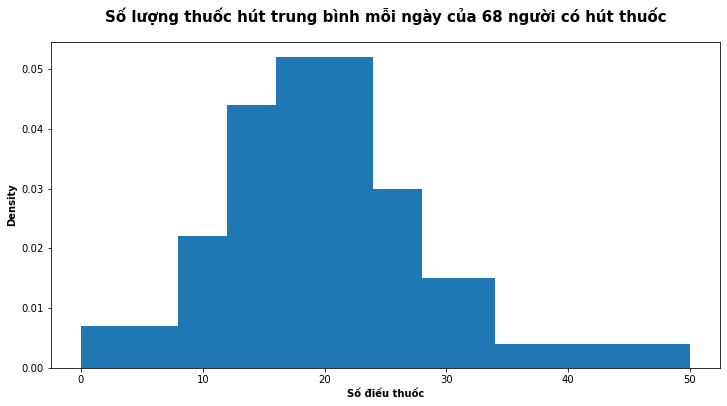

```python
fig, ax = plt.subplots(figsize=(12, 6))

# Cận dưới của các khoảng
sub_intervals = intervals[:-1]

# Do ta đã có được bảng tần số, nên để vẽ histogram ta sẽ dùng biểu đồ thanh với kích thước các khoảng bằng intervals_width, chiều cao theo density.
ax.bar(sub_intervals, density, intervals_width, align = 'edge')

ax.set_xlabel("Số điếu thuốc", fontweight = 'bold')
ax.set_ylabel("Density", fontweight = 'bold')
ax.set_title(
    "Số lượng thuốc hút trung bình mỗi ngày của 68 người có hút thuốc",
    fontsize = 15,
    fontweight = 'bold',
    pad = 20,
    loc = 'center')
plt.show()
```

**3. Vẽ biểu đồ tần suất tích lũy.**

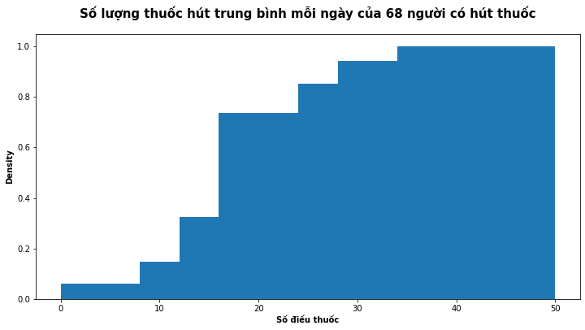

```python
fig, ax = plt.subplots(figsize=(12, 6))

# Biểu đồ tần suất tích lữy
ax.bar(sub_intervals, cumsum_prob, intervals_width, align = 'edge')

ax.set_xlabel("Số điếu thuốc", fontweight = 'bold')
ax.set_ylabel("Density", fontweight = 'bold')
ax.set_title(
    "Số lượng thuốc hút trung bình mỗi ngày của 68 người có hút thuốc",
    fontsize = 15,
    fontweight = 'bold',
    pad = 20,
    loc = 'center')

plt.show()
```

**4. Nhận xét**

**Câu 3.** Sau đây là số liệu lượng hành khách trên 50 chuyến tàu được khảo sát  
165 141 163 153 130 158 119 187 185 209  
177 147 166 154 159 178 187 139 180 143  
160 185 153 168 189 173 127 179 163 182  
171 146 174 149 126 156 155 174 154 150  
210 162 138 117 198 164 125 142 182 218

1. Tính trung bình (mean), trung vị (median), yếu vị (mode), phân vị (percentile) 10%, 90%.
2. Tính phạm vi (range), khoảng tứ phân vị (IQR - interquartile range), phương sai (variance), độ lệch chuẩn (standard deviation).
3. Nhận xét.

**1. Tính trung bình (mean), trung vị (median), yếu vị (mode), phân vị (percentile) 10%, 90%.**

```python
num_of_passengers = "165 141 163 153 130 158 119 187 185 209\
 177 147 166 154 159 178 187 139 180 143\
 160 185 153 168 189 173 127 179 163 182\
 171 146 174 149 126 156 155 174 154 150\
 210 162 138 117 198 164 125 142 182 218"
series_num_of_passengers = pd.Series([int(e) for e in num_of_passengers.split(' ')])

# Tính trung bình
mean = np.mean(series_num_of_passengers)
print('Số hành khác trung bình trên mỗi chuyến tàu là {}'.format(mean))

# Tính trung vị
median = np.median(series_num_of_passengers)
print('Trung vị là {}'.format(median))

# Tính yếu vị
import statistics as stat
mode = stat.multimode(series_num_of_passengers)
print('Yếu vị là {}'.format(mode))

# Tính phân vị 10%, 90%
percentile_0f_10, percentile_of_90 = np.percentile(series_num_of_passengers, [10, 90])
print('Các phân vị 10% là {} và 90% là {}'.format(percentile_0f_10, percentile_of_90))
```

```
Số hành khác trung bình trên mỗi chuyến tàu là 162.6
Trung vị là 162.5
Yếu vị là [163, 153, 187, 185, 154, 182, 174]
Các phân vị 10% là 129.7 và 90% là 187.2
```

**2. Tính phạm vi (range), khoảng tứ phân vị (IQR - interquartile range), phương sai (variance), độ lệch chuẩn (standard deviation).**

```python
# Tính phạm vi
range = np.max(series_num_of_passengers) - np.min(series_num_of_passengers)
print('Phạm vi là {}'.format(range))

# Khoảng tứ phân vị (IQR - interquartile range)
lower_quartile, upper_quartile = np.percentile(series_num_of_passengers, [25, 75])
IQR = upper_quartile - lower_quartile
print('Khoảng tứ phân vị là {}'.format(IQR))

# Phương sai
variance = np.var(series_num_of_passengers)
print('Phương sai là {}'.format(variance))

# Độ lệch chuẩn
std = np.std(series_num_of_passengers)
print('Độ lệch chuẩn là {}'.format(std))
```

```
Phạm vi là 101
Khoảng tứ phân vị là 31.25
Phương sai là 534.16
Độ lệch chuẩn là 23.11190169587955
```

**3. Nhận xét**

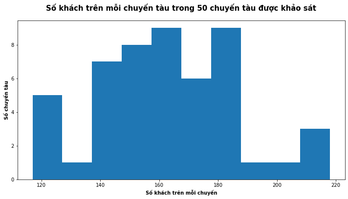

```python
fig, ax = plt.subplots(figsize=(12, 6))
ax.hist(series_num_of_passengers)
ax.set_xlabel("Số khách trên mỗi chuyến", fontweight = 'bold')
ax.set_ylabel("Số chuyến tàu", fontweight = 'bold')
ax.set_title(
    "Số khách trên mỗi chuyến tàu trong 50 chuyến tàu được khảo sát",
    fontsize = 15,
    fontweight = 'bold',
    pad = 20,
    loc = 'center')

plt.show()
```

Với 50 chuyến tàu được khảo sát, số hành khách trên mỗi chuyến phân bố tương đối đều nhau, rải rác trong khoảng từ 135 đến 185 khách. Với số khách trung bình trên một chuyến là 162.6.

1. “Trích và mô tả” dữ liệu của Việt Nam (mã quốc gia là VN).
2. “So sánh” dữ liệu của Việt Nam với Thái Land (mã quốc gia là TH).

**Bài làm**

**1. “Trích và mô tả” dữ liệu của Việt Nam (mã quốc gia là VN).**

```python
covid = pd.read_csv("WHO-COVID-19-global-data.csv")

# Dữ liệu covid Việt nam
covid_Vietnam = covid.loc[covid['Country_code'] == 'VN']
covid_Vietnam
```

|  | Date_reported | Country_code | Country | WHO_region | New_cases | Cumulative_cases | New_deaths | Cumulative_deaths |
| --- | --- | --- | --- | --- | --- | --- | --- | --- |
| 178408 | 2020-01-03 | VN | Viet Nam | WPRO | 0 | 0 | 0 | 0 |
| 178409 | 2020-01-04 | VN | Viet Nam | WPRO | 0 | 0 | 0 | 0 |
| 178410 | 2020-01-05 | VN | Viet Nam | WPRO | 0 | 0 | 0 | 0 |
| 178411 | 2020-01-06 | VN | Viet Nam | WPRO | 0 | 0 | 0 | 0 |
| 178412 | 2020-01-07 | VN | Viet Nam | WPRO | 0 | 0 | 0 | 0 |
| ... | ... | ... | ... | ... | ... | ... | ... | ... |
| 179172 | 2022-02-05 | VN | Viet Nam | WPRO | 11594 | 2315689 | 84 | 38147 |
| 179173 | 2022-02-06 | VN | Viet Nam | WPRO | 12170 | 2327859 | 114 | 38261 |
| 179174 | 2022-02-07 | VN | Viet Nam | WPRO | 14112 | 2341971 | 63 | 38324 |
| 179175 | 2022-02-08 | VN | Viet Nam | WPRO | 16815 | 2358786 | 100 | 38424 |
| 179176 | 2022-02-09 | VN | Viet Nam | WPRO | 21909 | 2380695 | 97 | 38521 |

769 rows × 8 columns

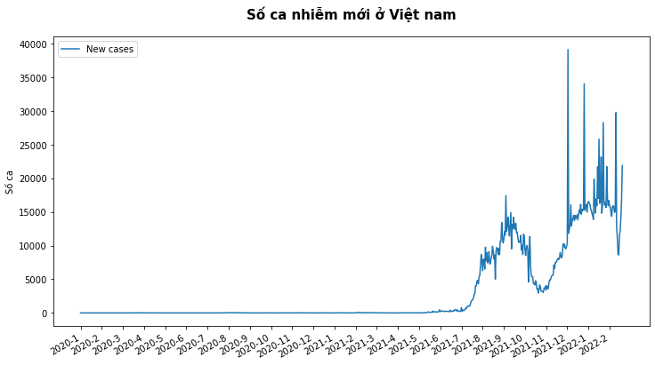

```python
fig, ax = plt.subplots(figsize = (12, 6))

# Vẽ các ca nhiễm mới ở Việt nam
new_cases_vn = covid_Vietnam['New_cases'].values
ax.plot(new_cases_vn, label = 'New cases')

x_labels = ['2020-1', '2020-2', '2020-3', '2020-4', '2020-5', '2020-6',
            '2020-7', '2020-8', '2020-9', '2020-10', '2020-11', '2020-12',
            '2021-1', '2021-2', '2021-3', '2021-4', '2021-5', '2021-6',
            '2021-7', '2021-8', '2021-9', '2021-10', '2021-11', '2021-12',
            '2022-1', '2022-2']

x = np.arange(0, 779, 30)
ax.set_ylabel('Số ca')
ax.set_xticks(x)
ax.set_xticklabels(x_labels)

for label in ax.get_xticklabels():
    label.set(rotation=30, horizontalalignment='right')

ax.set_title(
    "Số ca nhiễm mới ở Việt nam",
    fontsize = 15,
    fontweight = 'bold',
    pad = 20,
    loc = 'center')

plt.legend()
plt.show()
```

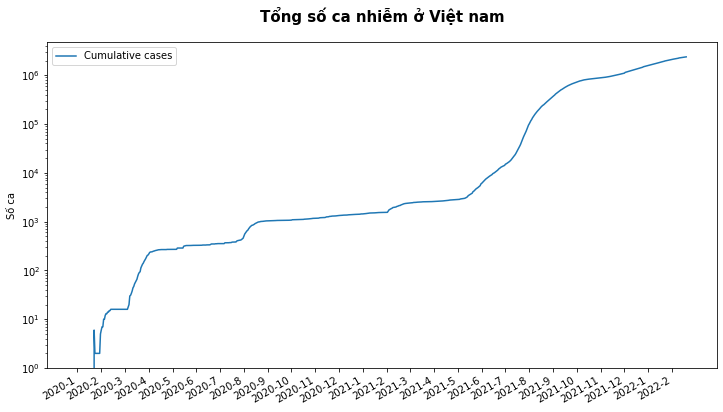

```python
fig, ax = plt.subplots(figsize = (12, 6))

# Vẽ tổng số ca nhiễm ở Việt nam
cumulative_cases_vn = covid_Vietnam['Cumulative_cases'].values
ax.plot(cumulative_cases_vn, label = 'Cumulative cases')

x_labels = ['2020-1', '2020-2', '2020-3', '2020-4', '2020-5', '2020-6',
            '2020-7', '2020-8', '2020-9', '2020-10', '2020-11', '2020-12',
            '2021-1', '2021-2', '2021-3', '2021-4', '2021-5', '2021-6',
            '2021-7', '2021-8', '2021-9', '2021-10', '2021-11', '2021-12',
            '2022-1', '2022-2']

x = np.arange(0, 779, 30)
ax.set_ylabel('Số ca')
ax.set_xticks(x)
ax.set_xticklabels(x_labels)

ax.set_yscale('log')

for label in ax.get_xticklabels():
    label.set(rotation=30, horizontalalignment='right')

ax.set_title(
    "Tổng số ca nhiễm ở Việt nam",
    fontsize = 15,
    fontweight = 'bold',
    pad = 20,
    loc = 'center')

plt.legend()
plt.show()
```

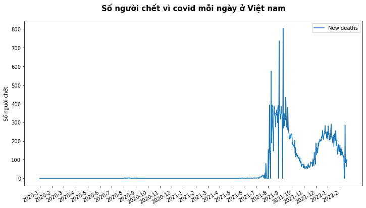

```python
fig, ax = plt.subplots(figsize = (12, 6))

# Vẽ tổng số người chết mỗi ngày vì covid
new_deaths_vn = covid_Vietnam['New_deaths'].values
ax.plot(new_deaths_vn, label = 'New deaths')

x_labels = ['2020-1', '2020-2', '2020-3', '2020-4', '2020-5', '2020-6',
            '2020-7', '2020-8', '2020-9', '2020-10', '2020-11', '2020-12',
            '2021-1', '2021-2', '2021-3', '2021-4', '2021-5', '2021-6',
            '2021-7', '2021-8', '2021-9', '2021-10', '2021-11', '2021-12',
            '2022-1', '2022-2']

x = np.arange(0, 779, 30)
ax.set_ylabel('Số người chết')
ax.set_xticks(x)
ax.set_xticklabels(x_labels)

#ax.set_yscale('log')

for label in ax.get_xticklabels():
    label.set(rotation=30, horizontalalignment='right')

ax.set_title(
    "Số người chết vì covid mỗi ngày ở Việt nam",
    fontsize = 15,
    fontweight = 'bold',
    pad = 20,
    loc = 'center')

plt.legend()
plt.show()
```